# Sensitivity of the Pareto front

Fabrice Zaoui

September 16 2020

# Short Description

**caRamel** is a multiobjective evolutionary algorithm combining the MEAS algorithm and the NGSA-II algorithm.

Download the package from CRAN or [GitHub](https://github.com/fzao/caRamel) and then install and load it.

It is possible to compute the first order derivatives of the Pareto front with **caRamel** by setting the logical parameter *sensitivity* to TRUE.

```r
library(caRamel)
```

# Test function

## Schaffer

[*Schaffer*](https://en.wikipedia.org/wiki/File:Schaffer_function_1.pdf) test function has two objectives with one variable.

```r
schaffer <- function(i) {
  s1 <- x[i,1] * x[i,1]
  s2 <- (x[i,1] - 2) * (x[i,1] - 2)
  return(c(s1, s2))
}
```

Note that :

- parameter *i* is mandatory for the management of parallelism.
- the variable **must be named** *x* and is a matrix of size [npopulation, nvariables].

For instance, the variable will lie in the range [-10, 10]:

```r
nvar <- 1 # number of variables
bounds <- matrix(data = 1, nrow = nvar, ncol = 2) # upper and lower bounds
bounds[, 1] <- -10 * bounds[, 1]
bounds[, 2] <- 10 * bounds[, 2]
```

Both functions are to be minimized:

```r
nobj <- 2 # number of objectives
minmax <- c(FALSE, FALSE) # min and min
```

Before calling **caRamel** in order to optimize the Schaffer’s problem, some algorithmic parameters need to be set:

```r
popsize <- 100 # size of the genetic population
archsize <- 100 # size of the archive for the Pareto front
maxrun <- 1000 # maximum number of calls
prec <- matrix(1.e-3, nrow = 1, ncol = nobj) # accuracy for the convergence phase
```

## Optimization

Then the minimization problem can be launched with a sensitivity analysis:

```r
results <-
  caRamel(nobj,
          nvar,
          minmax,
          bounds,
          schaffer,
          popsize,
          archsize,
          maxrun,
          prec,
          carallel=FALSE,
          sensitivity=TRUE) # sensitivity required
```

```
## Beginning of caRamel optimization <-- Tue May 12 11:01:25 2026
```

```
## Number of variables : 1
```

```
## Number of functions : 2
```

```
## Computing the sensitivity of the Pareto front...
```

```
## Done in 1.88975501060486 secs --> Tue May 12 11:01:27 2026
```

```
## Size of the Pareto front : 98
```

```
## Number of calls : 1118
```

Test if the convergence is successful:

```r
print(results$success==TRUE)
```

```
## [1] TRUE
```

Plot the Pareto front:

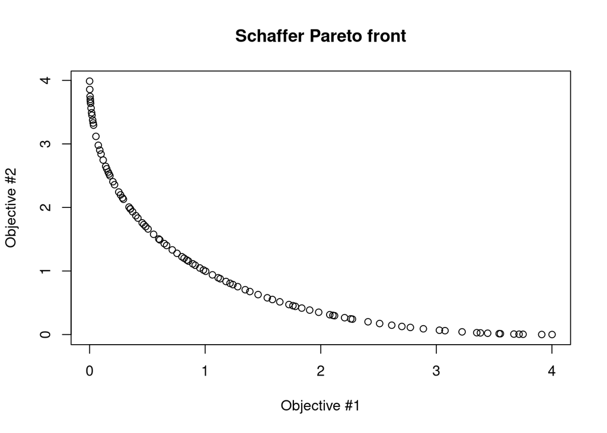

```r
plot(results$objectives[,1], results$objectives[,2], main="Schaffer Pareto front", xlab="Objective #1", ylab="Objective #2")
```

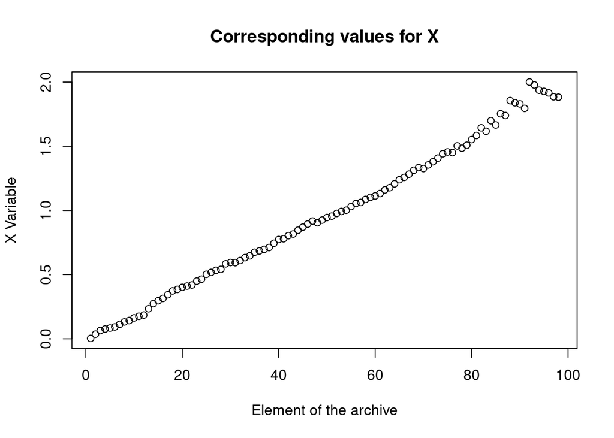

```r
plot(results$parameters, main="Corresponding values for X", xlab="Element of the archive", ylab="X Variable")
```

## Sensitivity

The sensitivity of the Pareto front is evalutated by computing first order derivatives. For each of the objective, one Jacobian matrix is computed:

```r
names(results$derivatives)
```

```
## [1] "Jacobian_1" "Jacobian_2"
```

Plot the sensitivity for the first objective:

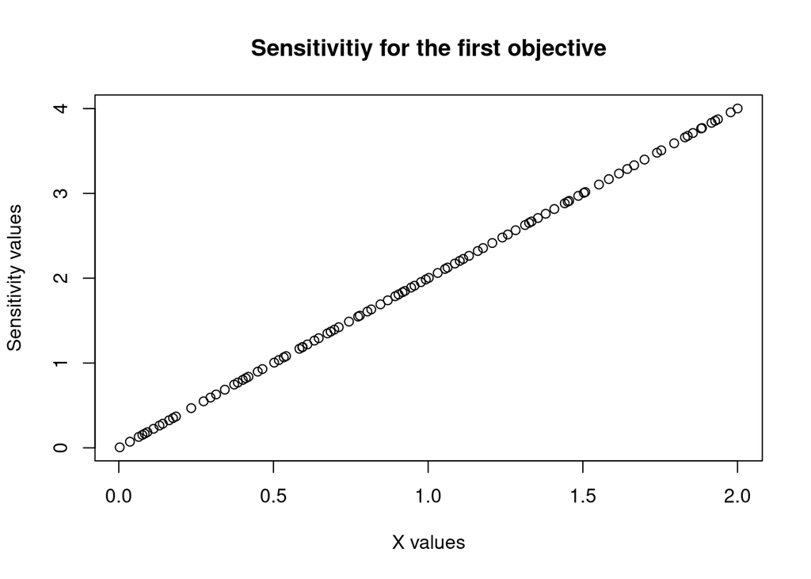

```r
plot(results$parameters, results$derivatives$Jacobian_1, main="Sensitivitiy for the first objective", ylab="Sensitivity values", xlab="X values")
```

Plot the histogram for the second objective:

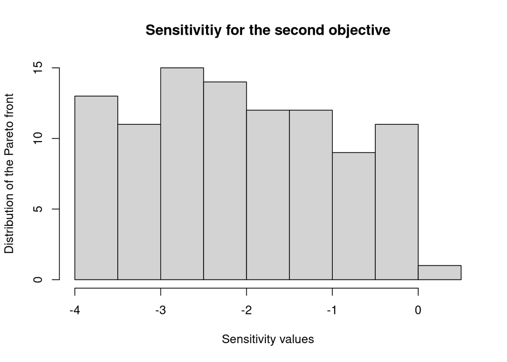

```r
hist(results$derivatives$Jacobian_2, main="Sensitivitiy for the second objective", xlab="Sensitivity values", ylab="Distribution of the Pareto front")
```

Plot the sensitivity of the Pareto front for the two objectives:

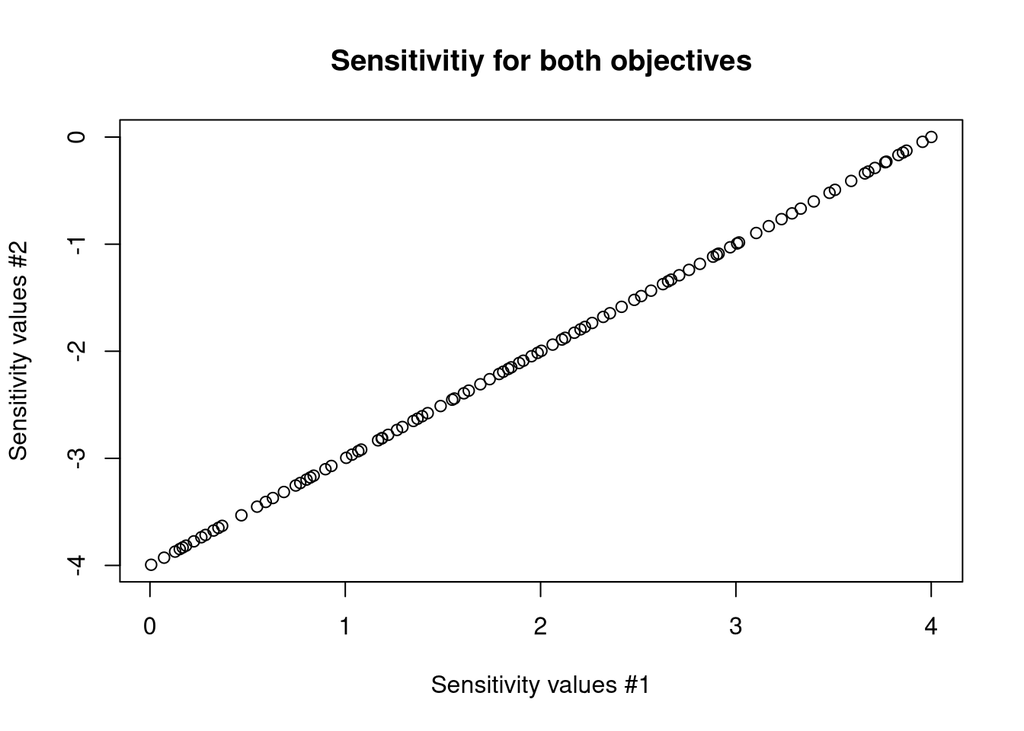

```r
plot(results$derivatives$Jacobian_1, results$derivatives$Jacobian_2, main="Sensitivitiy for both objectives", ylab="Sensitivity values #2", xlab="Sensitivity values #1")
```